# Session I: R Introduction

### 8. Subsetting data frames

#### 8.1. Subsetting using “**subset**”

```r
# Get rows where gene_name column is == to "GLI2"
subset(gencode, gene_name=="GLI2")

# Get rows where gene_name column has == to "GLI2"
subset(gencode, gene_name%in%c("GLI2","HLF"))

# Select genes in Chromosome 21
gencode.21 <- subset(gencode, chromosome=="chr21")
```

#### 8.2. Subsetting using “**which**”

The command “which” detect the index of elements matching a logical comparison.

```r
# See the row number of genes located in the mitochondrial chromosome"
which(gencode$chromosome=="chrM")

# Subset the data frame and keep it in a object named gencode.mt
gencode.mt <- gencode[which(gencode$chromosome=="chrM"), ]

# It is also possible to make in this way:
gencode.mt <- gencode[gencode$chromosome=="chrM", ]

# To check the number of genes that in this case match with the number of row.
nrow(gencode.mt)
```

### 9. Control strutures:

#### 9.1. Control strutures: “if”"

**Syntax:** if (Condition 1=TRUE) { Command 1 }

```r
a=3
b=2

if(a > b){
  print("b is less than a")
}
```

#### 9.2. Control strutures: “if-else”

**Syntax:** if (Condition 1=TRUE) { Command 1 } else { Command 2}

```r
if(a > b){
  print("b is less than a")
}else{
    print("b is not less than a")
}
```

#### 9.3. Control strutures: “if-else”"

```r
x.num <- c(1:5)
print(x.num)
```

```
## [1] 1 2 3 4 5
```

```r
ifelse(test = x.num==3, yes = TRUE, no = FALSE)
ifelse(test = x.num==3, yes = 1, no = 0 )

# The syntax is semi-automatic by the order of elements.
ifelse(x.num==3, "black", "red")
color.result <- ifelse(x.num==3, "black", "red")
```

#### 9.4. Control strutures: “for”

```r
for(i in x.num){
  print(i)
}
```

Here we use color.result after using ifelse on “x.num” to analyse which value will be in each step.

```r
for(i in x.num){
  print(paste("The number",i,"is the color", color.result[i], sep=" "))

}
```

### 10. Plots

Load again the file with gencode data. Here you have a summary of the main graphical parameters.

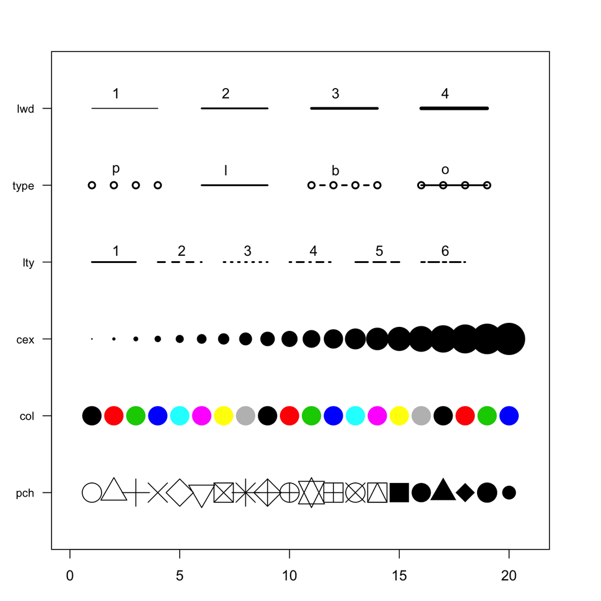

```r
gencode <- read.table("https://www.dropbox.com/s/le9vs2n51lsxlw1/gencode_GRCh38.txt?dl=1",
                      header=TRUE,
                      stringsAsFactors = FALSE)
```

#### 10.1. Scatter plot

```r
gencode.7 <- subset(gencode, chromosome=="chr7")
gencode.7$position <- gencode.7$start + (gencode.7$end - gencode.7$start)

plot(x = gencode.7$position/1E6,
     y = length(gencode.7$position):1,
     col=ifelse(gencode.7$type=="miRNA","red","grey"),
     cex=ifelse(gencode.7$type=="miRNA",0.5,0.1),
     main="miRNA position",
     xlab="Genome position (Mbases)",
     ylab="Gene index")
abline(v=60)
```

#### 10.2. Histogram

Histograms are useful to explore the distribution of a set of values.

```r
hist(x = (gencode$end - gencode$start),
     xlab="Gene length",
     main = "Gene length distribution",
     col="blue",
     breaks = 20 )
```

#### 10.3. Density plot

```r
gene.length.density <- density(x = log10(gencode$end - gencode$start) , bw = 0.1)
# Have a look the structure of the density object
class(gene.length.density)
str(gene.length.density)
```

```r
# The density object can be directly used for plot
plot(x = gene.length.density,
     xlab="Gene length",
     main = "Gene length distribution",
     col="blue")
```

> **Training exercise:** Repeat the density function plot using multiple different bandwidth values. Does the curve change?

Now, we will compare two distributions within the same plot.

```r
gencode.PC <- subset(gencode, type=="protein_coding")

gene.length.density.PC <- density(x = log10(gencode.PC$end - gencode.PC$start) , bw = 0.1)

plot(x = gene.length.density,
     xlab="Gene length",
     main = "Gene length distributions",
     col="blue",
     xlim=c(0,7),
     ylim=c(0,0.7))

lines(gene.length.density.PC,
      col="red",
      lwd=3)
```